# Forecasting client retention — A machine-learning approach - ScienceDirect

[figure not shown]

[figure not shown]

[figure not shown]

[figure not shown]

## [Journal of Retailing and Consumer Services](https://www.sciencedirect.com/science/journal/09696989)

[Volume 52](https://www.sciencedirect.com/science/journal/09696989/52/supp/C), January 2020, 101918

# Forecasting client retention — A machine-learning approach

[Satu ElisaSchaeffer](https://www.sciencedirect.com/science/article/pii/S0969698919302668?via%3Dihub#!)[Sara VeronicaRodriguez Sanchez](https://www.sciencedirect.com/science/article/pii/S0969698919302668?via%3Dihub#!)

https://doi.org/10.1016/j.jretconser.2019.101918[Get rights and content](https://s100.copyright.com/AppDispatchServlet?publisherName=ELS&contentID=S0969698919302668&orderBeanReset=true)

## Abstract

In the age of big data, companies store practically all data on any client transaction. Making use of this data is commonly done with machine-learning techniques so as to turn it into information that can be used to drive business decisions. Our interest lies in using data on prepaid unitary services in a business-to-business setting to forecast client retention: whether a particular client is at risk of being lost *before* they cease being clients. The purpose of such a forecast is to provide the company with an opportunity to reach out to such clients as an effort to ensure their retention.

We work with monthly records of client transactions: each client is represented as a series of purchases and consumptions. We vary (1) the length of the time period used to make the forecast, (2) the length of a period of inactivity after which a client is assumed to be lost, and (3) how far in advance the forecast is made. Our experimental work finds that current machine-learning techniques able to adequately predict, well in advance, which clients will be lost. This knowledge permits a company to focus marketing efforts on such clients as early as three months in advance.

## Keywords

Client retention

Sales forecasting

Machine learning

Prepaid unitary services

## 1. Introduction

The sales of *unitary prepaid services* has become a pervasive business model. It is present in cleaning services (such as prepaid car-wash tickets for a taxi company), telecommunications (prepaid minutes and megabytes on cell phones), and delivery services (including prepaid shipping labels for on-line retail). Huang et al. (2015) reports that prepaid clients have a significantly higher *churn rate* (on average 9.4 percent) than postpaid clients (on average 5.2 percent), meaning that a prepaid customer is almost twice as likely to be a lost client. Understanding the factors that influence whether a specific client is retained offers a competitive advantage (Ankenbruck, 2017).

We work with customer transaction data of unitary, prepaid business-to-business services, although the prepaid-service business model extends also to business-to-consumer markets. Our goal is to determine *beforehand* which clients will be lost, although we do not, in this work, determine the *cause* of the loss — whether it is due to the client switching to a competitor, a discontinued need for the service, or some other reason. This process, best described as *forecasting* client retention, has not yet been widely studied (Ngai et al., 2009; Sabbeh, 2018; Soltani and Navimipour, 2016).

We propose and test a methodology for determining one or more months beforehand which clients will be retained and which will be lost. We vary (1) the length of the time period of client transaction data used to make the classification, (2) the length of the period of inactivity used to assume that a client has been lost, and (3) the forecast horizon of how many months in advance the classification into lost and retained clients is made. We test the methodology using multiple with machine-learning techniques that existing literature has found well-suited for this type of tasks. Our experimental findings indicate that several methods produce useful classifications as far as three months in advance.

The remainder of the paper is organized as follows: in Section 2 we first discuss related literature, after which we explain detail the calculations done to prepare the input data for the classifiers. We then present the experimental setup and the results we obtain in Section 3. We discuss the implications of the findings in Section 4 and conclude the present work in Section 5.

## 2. Theory

The concept of *Customer Relationship Management* (CRM) emerged in early twentieth century. CRM helps an organization to gain knowledge that allows it to understand client behavior and relationships better, and hence to improve client acquisition, retention, and profitability (Sabbeh, 2018; Soltani and Navimipour, 2016). Although there is no single, universally accepted definition (Kracklauer et al., 2004; Ngai et al., 2009; Parvatiyar and Sheth, 2001; Swift, 2000), the one given by Ling and Yen (2016) is popular: CRM comprises a set of processes and enabling systems supporting a business strategy to build long term, profitable relationships with specific clients.

CRM is a four-stage process with respect to clients: *identification*, *attraction*, *development*, and *retention*. Customer retention refers to actions taken by an organization to ensure client loyalty and avoid client migration, including tasks such as one-to-one marketing, loyalty programs, and complaints management. Retaining existing clients is usually easier and less expensive than gaining new clients (Derby, 2018).

We refer the reader to the review of Sabbeh (2018) for more details on CRM. Also Soltani and Navimipour (2016) present a comprehensive study and survey on CRM mechanisms for 2009–2015, focused on five categories: E-CRM, knowledge management, data mining, data quality, and social CRM.

We start with a review of related work in Section 2.1. Then, in Section 2.2 we describe the data used in the study in terms of quantity, composition, and statistical properties, after which we describe in Section 2.3 our mechanism for determining which of the clients are considered lost, based on the aforementioned statistical findings. We conclude the theoretical discussion by describing the characterization done to the client time series to use as input to the machine-learning algorithms in Section 2.4.

### 2.1. Related work

*Data Mining* (DM) refers to collecting, storing, and analyzing data in order to apply statistics and computational methods to derive useful information from said data. In economics, it is often called *business intelligence*. Naturally, DM techniques are widely applied in CRM. Ngai et al. (2009) provide a literature review on the use of DM for CRM in 2000–2006, reporting that active research is largely focused on client retention and that the main elements of client retention include one-to-one marketing, loyalty programs, and complaints management.

Application of *Machine Learning* (ML) on CRM is an active research area. ML offers a variety of computational methods for DM, especially in the area of automated classification, that is, the task of dividing a data set into two or more subgroups. For details on ML, we refer the reader to the textbook of Marsland (2014). As we do not develop any ML approaches in this work, but instead only employ existing methods as provided by commonly-used libraries — with the hope of thus encouraging companies to adopt the suggested practice of forecasting client retention — we do not enter into a detailed discussion of the workings of the ML methods themselves, for brevity and clarity.

For readers unfamiliar with the machine-learning methods applied in this work, they all share the following general principle:

**1.**

Some data of interest is presented, accompanied with pre-established *class labels* — in our case, the data consists of client-transaction time series and each client is labeled as either “lost” or “retained”.

**2.**

The data is *characterized* in some feature space, representing each data entity as a vector of characteristics.

**3.**

A *classifier* is then *trained* by presenting it some of the characteristic vectors. As the classifier produces a suggested class label as output, feedback is given: the internal configuration is adjusted if the suggested label did not match the pre-established class label; this is known as *supervised learning.*

**4.**

The remaining characteristic vectors are used as input but without feedback to *test* the classifier. The resulting labels are then compared with the pre-established ones to establish the performance of the trained classifier.

The internal workings of the classifier for how to determine which label to suggest to a given input and how to adjust in case of errors depend on the machine-learning technique used.

In this section, we discuss the state of the art of applying ML in forecasting client retention. Our interest lies specifically in classifying prepaid client transaction data into clients that will be retained and clients that will be lost *ahead of time*, that is, one or more months before the loss takes place. As such literature is very scarce, we also consider efforts to forecast client retention for consumer settings, subscription-based sales, and regular retail. Table 1 provides a summary of related work over the past two decades, classifying published works that attend the task of forecasting client retention in terms of the machine-learning techniques they employ.

Table 1. A comparison of related work in 1998–2018.

| Publication | Year | Main technique(s) | Utilized data set(s) |
| --- | --- | --- | --- |
| Karp | 1998 | logistic regression | *no data analysis is reported* |
| Larivière and Van den Poel | 2005 | random forest, regression forest | financial services |
| Coussement and Van den Poel | 2008 | support vector machine, logistic regression, random forest | newspaper subscriptions |
| Tsai and Lu | 2009 | neural networks, self-organizing maps | telecom |
| Coussement et al. | 2010 | generalized additive models | newspaper subscriptions |
| Risselada et al. | 2010 | logistic regression, classification trees, bagging | internet service provider, health insurance |
| De Bock and Van den Poel | 2011 | ensemble techniques | bank, telecom, retail |
| Ballings and Van den Poel | 2012 | logistic regression, classification trees, bagging | newspaper subscriptions |
| Chen et al. | 2012 | support vector machine | retail, online transactions, telecom |
| De Bock and Van den Poel | 2012 | generalized additive models | banking |
| Verbeke et al. | 2012 | *numerous* | telecom |
| Miguéis et al. | 2013 | logistic regression, multivariate adaptive regression splines | retail |
| Ali and Arıtürk | 2014 | logistic regression, decision trees | private banking |
| Jahromi et al. | 2014 | decision trees, logistic regression | business-to-business |
| Ankenbruck | 2017 | logistic regression, decision trees, neural networks | home-delivery of dairy-product subscriptions |
| De Caigny et al. | 2018 | logistic regression, decision trees | financial services, retail, newspaper subscriptions, telecom, energy |
| Martínez et al. | 2018 | logistic regression and others | business-to-business |

Historically, related work initiates with the use of *logistic regression* (Kleinbaum and Klein, 2010) by Karp (1998) in 1998 and the technique is still in use two decades later (Martínez et al., 2018). The use of *classification trees* (Breiman et al., 1984), in particular *Random Forest* (Breiman, 2001), as well as the first use of a Support Vector Machine (Cortes and Vapnik, 1995) for subscription-based services (Coussement and Van den Poel, 2008; Larivière and Van den Poel, 2005) appear as alternative approaches during the first decade. The second decade is also mostly concentrated on determining subscription renewals such as newspaper and insurance (Ankenbruck, 2017; Ballings and Van den Poel, 2012; Coussement et al., 2010; De Caigny et al., 2018; Risselada et al., 2010) and contractual services such as telecommunications and banking (Ali and Arıtürk, 2014; Chen et al., 2012; De Bock and Van den Poel, 2011; Tsai and Lu, 2009; Verbeke et al., 2012), while a few works focus on consumer retail (Miguéis et al., 2013). The business-to-business aspect is attended to by only Jahromi et al. (2014) and Martínez et al. (2018), but without the prepaid aspect that is essential in our present work.

In terms of our present contribution, the meaningful insights of existing literature come in terms of what aspects of the data influence the outcome and which methods to employ. As in all application of machine learning, also in the context of forecasting client retention, the performance of any given machine-learning technique depends heavily on the characteristics of the data set (Risselada et al., 2010). Also, given a set of data, the selection of which subset of that data to use also affects the accuracy of the resulting classification (Amin et al., 2019). Sabbeh (2018) compare the performance of several machine-learning techniques for forecasting client retention using data from a telecommunications company. Their results indicate that Random Forest (Breiman, 2001) and ADA Boost (Freund and Schapire, 1997) have the best performance, whereas Support Vector Machine (Cortes and Vapnik, 1995) also achieves a good performance. The length of the time window (i.e., the amount of data used in making the forecast) was found to be logarithmically related to classification performance by Ballings and Van den Poel (Ballings and Van den Poel, 2012). Ankenbruck (2017) finds that detecting retained clients is easier than forecasting churn; in our case study, this is also the case. No existing work known to us carries out client retention forecasts for prepaid business-to-business transactions, for which we have no direct point of comparison for our results.

### 2.2. Client-transaction time series

We work with client-transaction records of a Mexican company that sells parcel-delivery as a prepaid service. The data fragment starts in January 2014 and ends in April 2017. We extracted the number of prepaid service sales to each client per month as well as the number of service consumptions of each client per month. We only analyze the clients for which both kinds of transactions are registered (the data provided by the company includes many clients that only have consumptions but no registered purchases, implying that those services were purchased through some alternative channel).

We combined the sales counts and the consumptions into a time series describing the client-side inventory of the purchased services: whenever the client purchases *p* units, the inventory goes up by *p*, and whenever the client consumes *c* units, the inventory goes down by *c* — we locate two data points per month, assuming that the purchase of new units occurs at the beginning of each month and that the consumption of existing units happens mid-month as a simplification. In future work, we are interested in analyzing individual transaction data where the exact time of purchase and/or consumption is known instead of the monthly binning present in the data we presently possess. See Table 2 for a summary of the related notation.

Table 2. Notation used in the formulation of the problem.

| Units purchased by client per time unit | *p* |
| --- | --- |
| Units consumed by client per time unit | *c* |
| Data points per month in each time series | 2 |
| Total number of clients in data set | *n* |
| Maximum length of a time series | *k* |
| Length of a useable time-series segment | $k*$ |
| Inactivity threshold as a number of data points | $ℓ$ |
| Length of the an included time-series segment | *λ* |
| Length of the forecast horizon | *δ* |
| Length of the time-series segment used as input | *ξ* |

Each time series contains at most $k=81$ data points: the initial stock estimate (zero if the series required no adjustment due to apparent initial inventory) and two data points for each of the 40 months in the recorded period — clients that were not yet active at the start of the examined time interval have less data, as do those that stopped being clients during the time interval. From each time series of $≤k$ observations, we eliminate any possible initial and final inactivity to obtain a time-series segment of $k′≤k$ data points. Any clients that have less than three months (six data points) of total activity are excluded from any further analysis. Similarly, if extracting the time-series fragment up until the first inactivity of at least $ℓ$ consecutive data points results in less than six remaining data points, the client is excluded from further analysis; we denote the length of this segment by $k*$.

A total of 34 clients have no inactivity whereas the longest inactivity present in the data set corresponds to 62 data points, which is 31 months. Fig. 1 shows examples of time series for three different clients; note that some have clearer periodicity than others, the lengths of the periods differ, and the magnitude of the level of inventory also varies. The first example has no clear periodicity and the first period of inactivity is at the end of the series, whereas the second example includes a short intermediate inactivity and a longer final one; the third example is clearly periodic and contains no periods of inactivity.

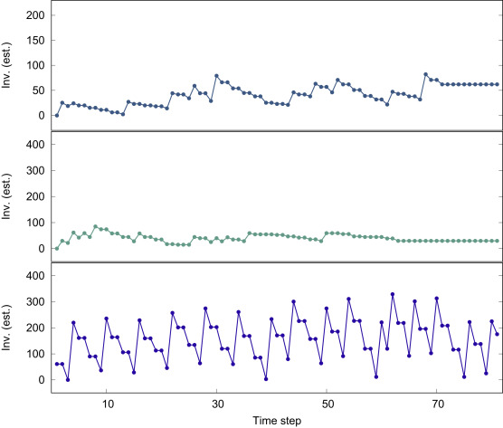

During the processing, we also extracted for each client the *longest* period of inactivity for both purchases and consumptions (i.e., the longest amount of consecutive months with no transaction of that type); we consider as a period of inactivity a sequence of months *before* and *after* which there had been transactions — the initial inactivity of a not-yet client and the final inactivity of an already-lost client are *not* included in this analysis, cropping the initial and final months that have no registered activity.

The histograms of the 1525 purchase inactivities and the 882 consumption inactivities as well as that of the 1934 combined periods of inactivity (that is, the client had no transactions of either kind in the course of at least one month) are shown in Fig. 2. In terms of the purchases, 473 clients had no periods of inactivity, whereas in terms of uses 1099 clients had no periods of inactivity — a total of 34 had no inactivity in the combined transaction time series. It is very common for a client to be inactive for a month — 917 occurrences, making up 47 percent of the periods of inactivity in the combined series) — and then to resume purchases and consumptions, but inactivities of eight months or more are not so common (299 cases, 15 percent). In our experiments, we work with inactivities from three to seven months, of which there are 474 cases in the combined series (possibly repeating more than once for a given client), accounting for 25 percent of the periods of inactivity from which the client did in fact return. We excluded the two-month inactivities of which there were 244 (13 percent) as the one-month inactivities were so common so as to limit the “false alarms” in which the marketing department is lead to believe that a client might be lost when in fact they are very likely to reactivate without any intervention.

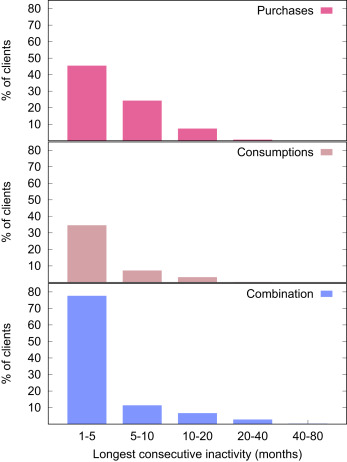

Fig. 2. Histograms of client inactivity.

The preprocessing of the data is done in Python 3.6.2, the statistical treatment in R 3.4.4, and the visualization in Gnuplot 5.0, using Gnu bash 3.2.57 for utilities such as grep, sed, and awk for additional data processing. All of the computational experiments were executed on an iMac with a 4 GHz Intel Core i7 processor running macOS Mojave (10.14.3) with 32 GB 1867 MHz DDR3 main memory.